# Multiple Linear Regression

Let’s compute $95\%$ confidence interval. In this case first we have to compute

```r
> e <- resid(modelPriceBedrooms)
> n <- length(e)
> beta1hat <- modelPriceBedrooms$coefficients[2]; beta1hat
bedrooms
72.26065
> SSE <- sum(e^2)
> MSE <- SSE / (n-2)
> Seps <- sqrt(MSE)
> SEbeta1 <- Seps / sqrt(sum((bedrooms - mean(bedrooms))^2)); SEbeta1
[1] 25.21457
> alpha <- 0.05
> t <- qt(1 - alpha/2, n - 2, lower.tail = TRUE)
> myCI(beta1hat, SEbeta1,t)
[1]  20.52462 123.99668
```

$H_0 : \beta_1 = 15$

$H_A : \beta_1 \neq 15$

Given $\alpha$ the critical area is

$$W_\alpha =\left\{\frac{|\hat{\beta}_1 - 15|}{SE(\beta_1)} \geq t_{1-\frac{\alpha}{2}; n-2}\right\}$$

```r
> b1 <- modelPriceBedrooms$coefficients[2]; b1
bedrooms
72.26065
> temp <- (b1 - 15) / SEbeta1; temp
bedrooms
2.270935
> pvalue <- 2 * pt(temp, n - 2, lower.tail = FALSE);pvalue
  bedrooms
0.03134009
```

The $p-value = 0.03134009 < \alpha = 0.05$, so we reject $H_0$.

3. Let us now model the dependence of the prices `list` of homes from this population from the number of `rooms`.

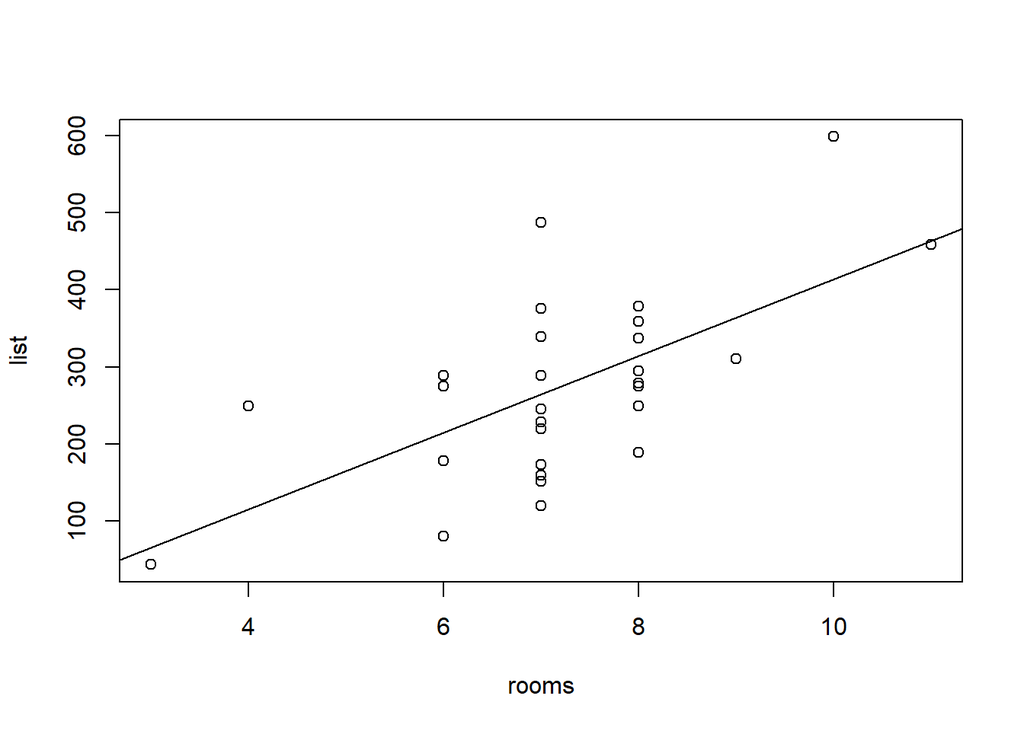

```r
> modelPriceRooms <- lm(list ~ rooms)
> plot(rooms, list)
> abline(lm(list ~ rooms))
```

```r
> summary(modelPriceRooms )

Call:
lm(formula = list ~ rooms)

Residuals:
    Min      1Q  Median      3Q     Max
-145.54  -54.16  -19.54   64.65  223.46

Coefficients:
            Estimate Std. Error t value Pr(>|t|)
(Intercept)   -84.10      87.20  -0.964 0.343355
rooms          49.81      11.85   4.204 0.000257 ***
---
Signif. codes:  0 '***' 0.001 '**' 0.01 '*' 0.05 '.' 0.1 ' ' 1

Residual standard error: 95.34 on 27 degrees of freedom
Multiple R-squared:  0.3956,    Adjusted R-squared:  0.3732
F-statistic: 17.67 on 1 and 27 DF,  p-value: 0.0002575
```

$$list = -84.10 + 49.81\ rooms + \varepsilon$$
Let us now answer the question: What is the influence of one more room on the price of the home?

One more room increases the price with $49.81*1000\$$. Let us now compute the corresponding $95\%$ confidence interval

```r
> e <- resid(modelPriceRooms)
> n <- length(e)
> beta1hat <- modelPriceRooms$coefficients[2]; beta1hat
   rooms
49.80666
> SSE <- sum(e^2)
> MSE <- SSE / (n-2)
> Seps <- sqrt(MSE)
> SEbeta1 <- Seps / sqrt(sum((rooms - mean(rooms))^2)); SEbeta1
[1] 11.84735
> alpha <- 0.05
> t <- qt(1 - alpha/2, n - 2, lower.tail = TRUE)
> myCI(beta1hat, SEbeta1,t)
[1] 25.49791 74.11540
```

4. Let us now model the dependence of the prices `list` of homes from this population from the points for `neighborhood`s.

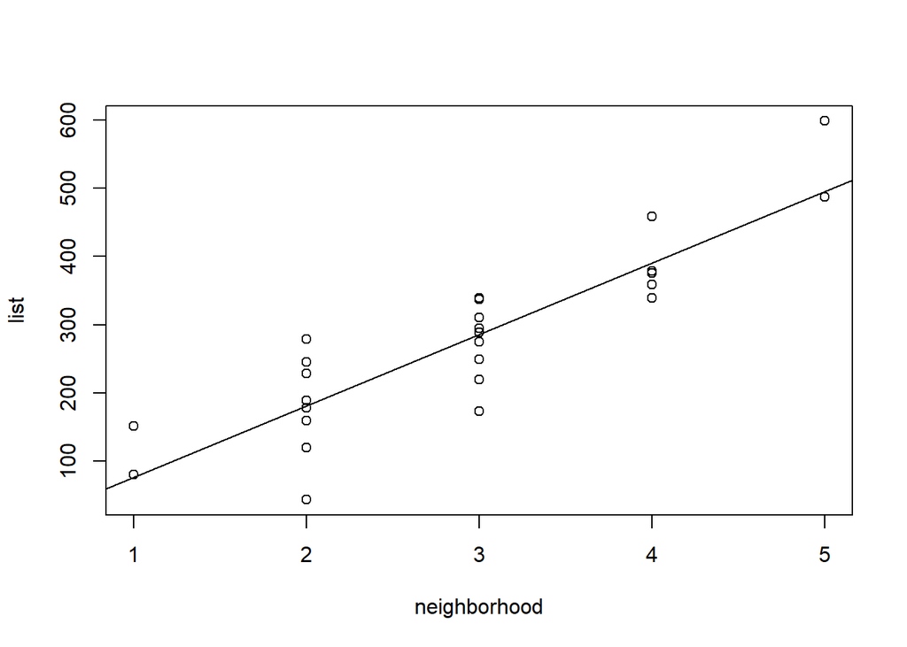

```r
> modelPriceNeighborhood <- lm(list ~ neighborhood)
> plot(neighborhood, list)
> abline(lm(list ~ neighborhood))
```

```r
> summary(modelPriceNeighborhood)

Call:
lm(formula = list ~ neighborhood)

Residuals:
     Min       1Q   Median       3Q      Max
-137.878  -31.504   -2.878   47.822  103.683

Coefficients:
             Estimate Std. Error t value Pr(>|t|)
(Intercept)    -28.75      33.17  -0.867    0.394
neighborhood   104.81      10.83   9.676 2.86e-10 ***
---
Signif. codes:  0 '***' 0.001 '**' 0.01 '*' 0.05 '.' 0.1 ' ' 1

Residual standard error: 58.02 on 27 degrees of freedom
Multiple R-squared:  0.7762,    Adjusted R-squared:  0.7679
F-statistic: 93.63 on 1 and 27 DF,  p-value: 2.863e-10
```

$$list = -28.75 + 104.81\ neighborhood + \varepsilon$$

If we compare the models with one independent variable considered in a), b), c), d) we observe that here we have the biggest Adjusted $R^2$. There for the `neighborhood` is the most important variable for the price `list` within this set of independent random variables.

Let us now answer the question: What is the change of the price for one more point in neighborhood?

One more point in neighborhood increases the price with $104.81*1000\$=104\ 810\$$. Let us now compute the corresponding $95\%$ confidence interval

```r
> e <- resid(modelPriceNeighborhood)
> n <- length(e)
> beta1hat <- modelPriceNeighborhood$coefficients[2]; beta1hat
neighborhood
    104.8129
> SSE <- sum(e^2)
> MSE <- SSE / (n-2)
> Seps <- sqrt(MSE)
> SEbeta1 <- Seps / sqrt(sum((neighborhood - mean(neighborhood))^2)); SEbeta1
[1] 10.8319
> alpha <- 0.05
> t <- qt(1 - alpha/2, n - 2, lower.tail = TRUE)
> myCI(beta1hat, SEbeta1,t)
[1]  82.58764 127.03808
```

5. Let us now model the dependence of the prices `list` of homes from this population from the points for `neighborhood`s and the number of `rooms`.

```r
> modelPriceNeighborhoodRooms <- lm(list ~ neighborhood + rooms)
> summary(modelPriceNeighborhoodRooms)

Call:
lm(formula = list ~ neighborhood + rooms)

Residuals:
    Min      1Q  Median      3Q     Max
-105.78  -29.34    5.01   35.78   65.31

Coefficients:
             Estimate Std. Error t value Pr(>|t|)
(Intercept)  -167.477     43.232  -3.874 0.000649 ***
neighborhood   89.115      9.465   9.416 7.32e-10 ***
rooms          25.559      6.300   4.057 0.000403 ***
---
Signif. codes:  0 '***' 0.001 '**' 0.01 '*' 0.05 '.' 0.1 ' ' 1

Residual standard error: 46.27 on 26 degrees of freedom
Multiple R-squared:  0.8629,    Adjusted R-squared:  0.8524
F-statistic: 81.85 on 2 and 26 DF,  p-value: 6.02e-12
```

$$list = -167.477 + 89.115\ neighborhood + 25.559\ rooms + \varepsilon$$

The coefficients for $neighborhood \neq 104.81$ and the coefficient for $rooms \neq 49.81$ as far as we have **multicollinearity**.

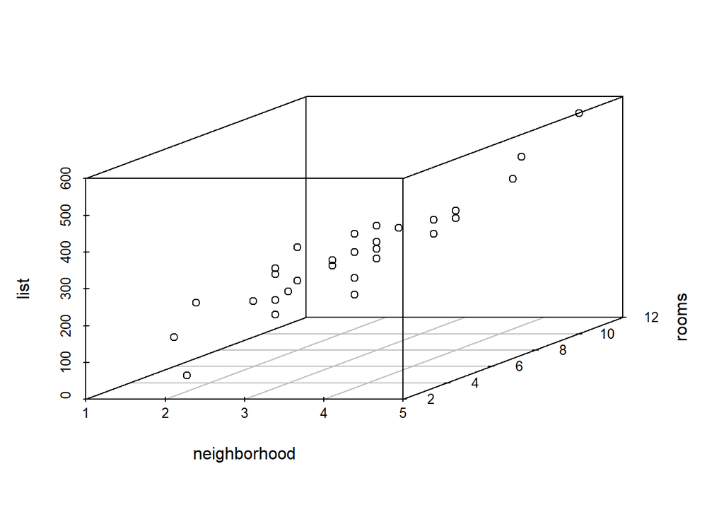

```r
> scatterplot3d(neighborhood,rooms,list)
```

```r
> open3d()
wgl
  2
> plot3d(neighborhood, rooms, list, col = "red", size = 3)
```

We can make regression models on different subsets. For example if we fix the number of neighbors we obtain.

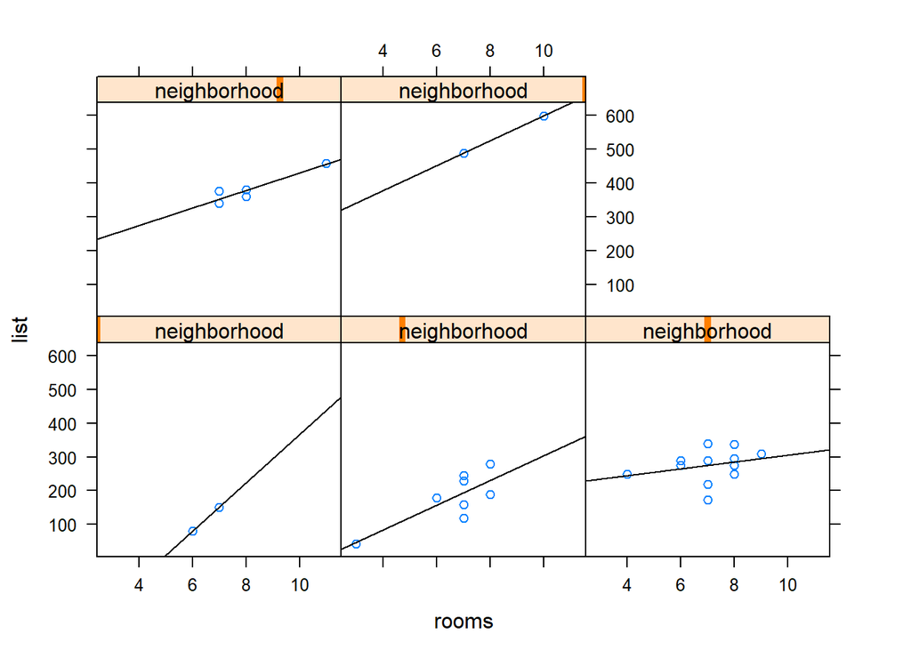

```r
> panel.lm <- function(x, y) {
+   panel.xyplot(x, y)
+   panel.abline(lm(y ~ x))
+ }
> xyplot(list ~ rooms | neighborhood, panel = panel.lm)
```

According to the data we observe that when we have the smallest number of points for neighbors the price is the most sensitive of the number of rooms.

6. Let us now model the dependence of the prices `list` of homes from this population from the number of `bedrooms` and points in `neighborhood`s.

```r
> modelPriceNeighborhoodBedrooms <- lm(list ~ neighborhood + bedrooms)
> summary(modelPriceNeighborhoodBedrooms)

Call:
lm(formula = list ~ neighborhood + bedrooms)

Residuals:
     Min       1Q   Median       3Q      Max
-104.443  -34.765   -0.783   21.009   98.122

Coefficients:
             Estimate Std. Error t value Pr(>|t|)
(Intercept)  -140.914     40.794  -3.454   0.0019 **
neighborhood   96.565      9.203  10.493 7.71e-11 ***
bedrooms       42.887     11.574   3.705   0.0010 **
---
Signif. codes:  0 '***' 0.001 '**' 0.01 '*' 0.05 '.' 0.1 ' ' 1

Residual standard error: 47.83 on 26 degrees of freedom
Multiple R-squared:  0.8535,    Adjusted R-squared:  0.8423
F-statistic: 75.75 on 2 and 26 DF,  p-value: 1.428e-11
```

$$list = -140.914 + 96.565\ neighborhood + 42.887\ bedrooms + \varepsilon$$

The coefficients for $neighborhood \neq 104.81$ and the coefficients for $bedrooms \neq 72.26$ as far as we have again **multicollinearity**.

If we compare the adjusted $R^2$ in this model and in the previous model considered in e) we observe that in e) adjusted $R^2$ is bigger. Therefore, the model in e) is better. So `rooms` is more important than `bedrooms`.

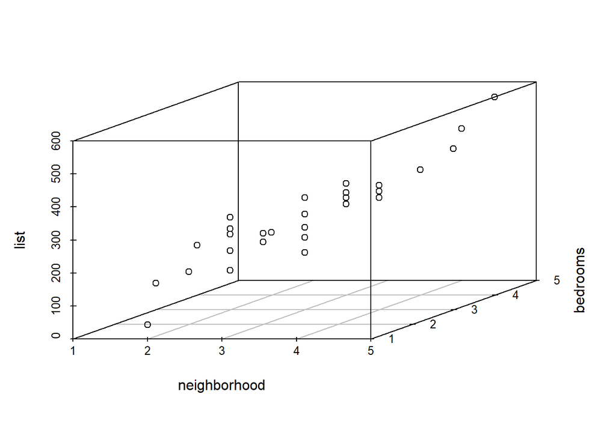

```r
> scatterplot3d(neighborhood, bedrooms, list)
```

```r
> open3d()
wgl
  3
> plot3d(neighborhood, bedrooms, list, col = "red", size = 3)
```

We can make regression models on different subsets. For example if we fix the number of neighbors we obtain.

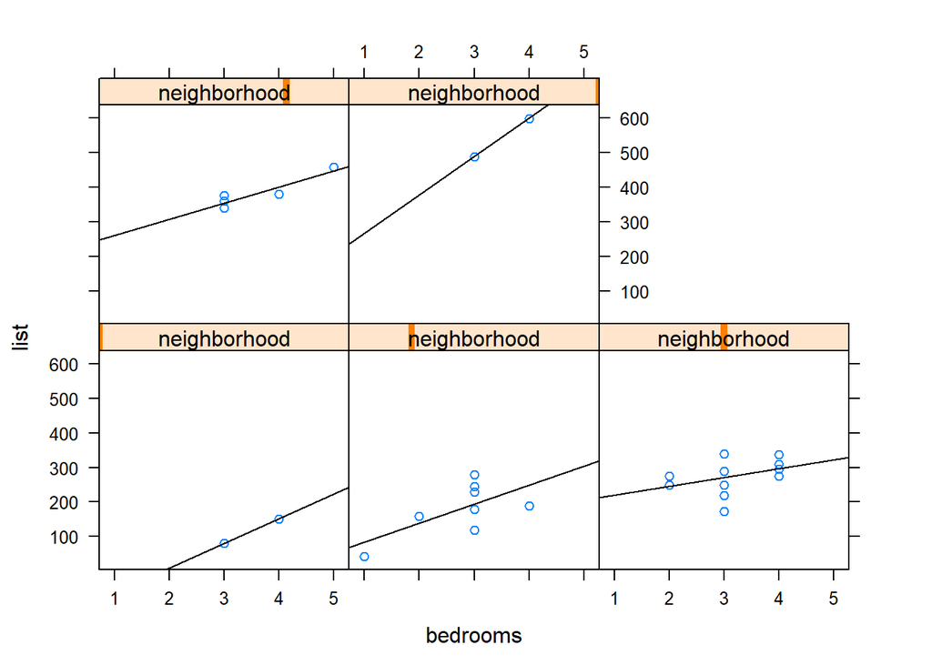

```r
> xyplot(list ~ bedrooms | neighborhood, panel = panel.lm)
```

We keep the neighborhood as a numerical variable to do the regression. The multiple linear regression model assumes that the regression line should have the same slope for all the levels.

Let us divide the population in three subsets with respect to the points for neighborhoods and then to make regression models.

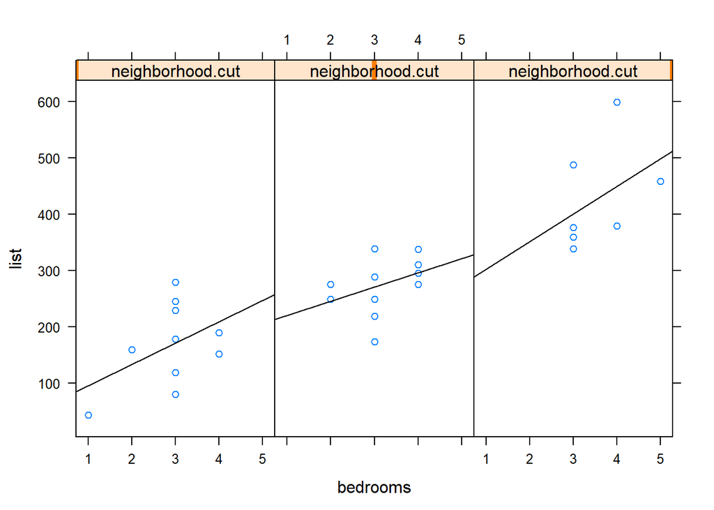

```r
> neighborhood.cut <- as.numeric(cut(neighborhood, c(0, 2, 3, 5), labels = c(1, 2, 3)))
> table(neighborhood.cut)
neighborhood.cut
 1  2  3
10 12  7
> xyplot(list ~ bedrooms | neighborhood.cut, panel = panel.lm, layout = c(3, 1))
```

```r
> model <- lm(list ~ bedrooms + neighborhood.cut)
> summary(model)

Call:
lm(formula = list ~ bedrooms + neighborhood.cut)

Residuals:
    Min      1Q  Median      3Q     Max
-107.59  -44.83  -11.57   31.15  164.90

Coefficients:
                 Estimate Std. Error t value Pr(>|t|)
(Intercept)        -63.16      51.53  -1.226   0.2313
bedrooms            36.74      15.86   2.317   0.0287 *
neighborhood.cut   116.76      16.53   7.062 1.69e-07 ***
---
Signif. codes:  0 '***' 0.001 '**' 0.01 '*' 0.05 '.' 0.1 ' ' 1

Residual standard error: 64.06 on 26 degrees of freedom
Multiple R-squared:  0.7372,    Adjusted R-squared:  0.717
F-statistic: 36.47 on 2 and 26 DF,  p-value: 2.846e-08
```

This mean that, if there are $0$ `bedrooms` then the house is worth

```r
> model$coefficients[1] + model$coefficients[3]*(1:3)
[1]  53.59894 170.36117 287.12340
```

if it has bad, neutral or good neighbors.

7. Let us now model the dependence of the prices `list` of homes from this population from the number of `full` bathrooms, `bedrooms` and points for `neighborhood`s.

```r
> complex.model <- lm(list ~ full + bedrooms + neighborhood)
> summary(complex.model)

Call:
lm(formula = list ~ full + bedrooms + neighborhood)

Residuals:
    Min      1Q  Median      3Q     Max
-93.763 -27.845  -8.004  23.452 102.635

Coefficients:
             Estimate Std. Error t value Pr(>|t|)
(Intercept)   -140.31      40.93  -3.428  0.00211 **
full            14.44      15.76   0.917  0.36815
bedrooms        40.48      11.90   3.401  0.00226 **
neighborhood    90.40      11.42   7.913 2.86e-08 ***
---
Signif. codes:  0 '***' 0.001 '**' 0.01 '*' 0.05 '.' 0.1 ' ' 1

Residual standard error: 47.98 on 25 degrees of freedom
Multiple R-squared:  0.8583,    Adjusted R-squared:  0.8413
F-statistic: 50.47 on 3 and 25 DF,  p-value: 9.452e-11
```

$$list = -140.31 + 14.44\ full + 40.48\ bedrooms + 90.40\ neighborhood + \varepsilon$$

This means that we need to pay $14.44*1 000\$ = 14\ 440\$$ per full bathroom. Could it possibly be $\$15\ 000$?

$H_0 : \beta_1 = 15$

$H_A : \beta_1 > 15$

```r
> SE <- 15.76
> t <- (14.44 - 15) / SE; t
[1] -0.03553299
> pvalue <- pt(t, df = 25, lower.tail = FALSE); pvalue
[1] 0.5140315
```

The $p-value = 0.5140315 > 0.05 = \alpha$, so we have no evidence to reject $H_0$.

8. Model the dependence of the prices `list` of homes from this population from the number of `rooms`, `bedrooms` and points for `neighborhood`s.

```r
> complex.model <- lm(list ~ rooms + bedrooms + neighborhood)
> summary(complex.model)

Call:
lm(formula = list ~ rooms + bedrooms + neighborhood)

Residuals:
     Min       1Q   Median       3Q      Max
-104.761  -29.449    1.635   31.158   73.909

Coefficients:
             Estimate Std. Error t value Pr(>|t|)
(Intercept)  -168.136     43.598  -3.856 0.000716 ***
rooms          18.019     11.800   1.527 0.139299
bedrooms       15.899     20.971   0.758 0.455452
neighborhood   90.688      9.766   9.286  1.4e-09 ***
---
Signif. codes:  0 '***' 0.001 '**' 0.01 '*' 0.05 '.' 0.1 ' ' 1

Residual standard error: 46.65 on 25 degrees of freedom
Multiple R-squared:  0.866, Adjusted R-squared:  0.8499
F-statistic: 53.87 on 3 and 25 DF,  p-value: 4.706e-11
```

$$list = -168.136 + 18.019\ room + 15.899\ bedrooms+ 90.688\ neighborhood + \varepsilon$$

We can immediately answer the question:Is it acceptable the intercept to be $0$?

$H_0 : \beta_0 = 0$

$H_A : \beta_0 \neq 0$

The $p-value = 0.000716 < 0.05 = \alpha$, so we reject $H_0$.

or

```r
> SEb0 <- 43.598
> temp <- abs(-168.136  - 0) / SEb0; temp
[1] 3.856507
> pvalue<- 2 * pt(temp, df = 25, lower.tail = FALSE); pvalue
[1] 0.0007155607
```

The $p-value = 0.000716 < 0.05 = \alpha$, so we reject $H_0$. The intercept $\beta_0$ is statistically significant.

Analogously we can check that the coefficients for `rooms` and `bedrooms` are not statistically significant or we can see this in `summary` output as far we have no `*` in the end of their rows. And although the adjusted $R^2 = 0.8499$ is relatively high. If we compare this model with models in e), f) the model in e) is the best one.

1. Determine the expected price of a home from this population if it has $3$ `rooms`, $2$ `bedrooms` and $2$ points for `neighborhood`s.

```r
> -168.136 + 18.019*3 + 15.899*2 + 90.688*2
[1] 99.095
```

The estimated `list` by the model is $99\ 095\$$.

10. Determine the expected price `list` of these homes having in mind the numbers of their `rooms` and `full` bathrooms and the points for `neighborhood`s.

```r
> complex.modelfull <- lm(list ~ full + rooms + neighborhood)
> summary(complex.modelfull)

Call:
lm(formula = list ~ full + rooms + neighborhood)

Residuals:
    Min      1Q  Median      3Q     Max
-94.636 -26.574  -4.456  30.781  71.364

Coefficients:
             Estimate Std. Error t value Pr(>|t|)
(Intercept)  -166.507     43.270  -3.848 0.000731 ***
full           14.882     15.133   0.983 0.334832
rooms          24.299      6.432   3.778 0.000875 ***
neighborhood   83.056     11.298   7.351 1.06e-07 ***
---
Signif. codes:  0 '***' 0.001 '**' 0.01 '*' 0.05 '.' 0.1 ' ' 1

Residual standard error: 46.29 on 25 degrees of freedom
Multiple R-squared:  0.868, Adjusted R-squared:  0.8522
F-statistic: 54.82 on 3 and 25 DF,  p-value: 3.894e-11
```

$$list = -166.507 + 14.882\ full + 24.299\ rooms + 83.056 \ neighborhood + \varepsilon$$

In this model the number of full bathrooms is not statistically significant and adjusted $R^2$ is less than in e) therefore the model in e) only with 2 independent variables is better.

```r
> yhat <- complex.modelfull$fitted.values; yhat
        1         2         3         4         5         6         7         8
 77.22524 101.52431 331.11633 306.81726 365.57428 291.93557 214.34378 184.58040
        9        10        11        12        13        14        15        16
267.63650  87.38412 208.87948 536.40927 199.46209 258.21911 194.73928 175.16302
       17        18        19        20        21        22        23        24
184.58040 282.51818 463.51206 380.45597 291.93557 306.81726 258.21911 477.65225
       25        26        27        28        29
267.63650 389.87335 389.87335 208.87948 267.63650
```

or

```r
> yhat <- complex.modelfull$coefficients[1] + complex.modelfull$coefficients[2] * full +  complex.modelfull$coefficients[3] * rooms + complex.modelfull$coefficients[4] * neighborhood; yhat
 [1]  77.22524 101.52431 331.11633 306.81726 365.57428 291.93557 214.34378
 [8] 184.58040 267.63650  87.38412 208.87948 536.40927 199.46209 258.21911
[15] 194.73928 175.16302 184.58040 282.51818 463.51206 380.45597 291.93557
[22] 306.81726 258.21911 477.65225 267.63650 389.87335 389.87335 208.87948
[29] 267.63650
```

11. Find and plot the errors(residuals) $\varepsilon_i$, $i = 1, 2, ..., n$ in the model in j).

```r
> e <- resid(complex.modelfull); e
         1          2          3          4          5          6          7
  2.774762  49.875690 -21.116328 -11.817256 -26.574278  45.564431  14.356221
         8          9         10         11         12         13         14
 60.419597  71.363503 -44.384116  70.120525  62.590726 -80.462091  30.780887
        15         16         17         18         19         20         21
 54.260719   2.836981 -25.580403   6.481815  24.487941  -4.455966 -42.935569
        22         23         24         25         26         27         28
-31.817256  16.780887 -18.652253 -48.636497 -30.873350 -10.873350 -19.879475
        29
-94.636497
```

or by using the formula

```r
> e <- list - yhat; e
 [1]   2.774762  49.875690 -21.116328 -11.817256 -26.574278  45.564431
 [7]  14.356221  60.419597  71.363503 -44.384116  70.120525  62.590726
[13] -80.462091  30.780887  54.260719   2.836981 -25.580403   6.481815
[19]  24.487941  -4.455966 -42.935569 -31.817256  16.780887 -18.652253
[25] -48.636497 -30.873350 -10.873350 -19.879475 -94.636497
```

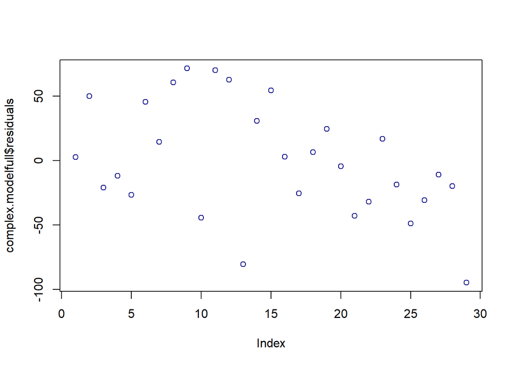

```r
> plot(complex.modelfull$residuals, col = "darkblue")
```

12. It is time to determine the mean square error (MSE) of the multiple model in j).

$$MSE = RSE^2 = S_\varepsilon^2 = \frac{1}{n - 4} \sum_{i=1}^n{(\hat{Y_i} - Y_i)^2} = \frac{1}{n - 4} \sum_{i=1}^n{\varepsilon_i^2}$$

It is an unbiased estimator of $\sigma_\varepsilon^2$. The denominator $n - 4$ comes from the fact that there are four coefficients estimated from the data: $\beta_0$, $\beta_1$, $\beta_2$ and $\beta_3$.

Let us remind that

$$SSE = \sum_{i=1}^n\varepsilon_i^2, \quad \quad MSE = \frac{SSE}{n - r} = \frac{SSE}{n - 4}$$

```r
> SSE <- sum(e^2); SSE
[1] 53580.19
> MSE <- SSE / (n - 4); MSE
[1] 2143.208
```

```r
> s <- sqrt(MSE); s
[1] 46.29479
```

```r
> summary(complex.modelfull)

Call:
lm(formula = list ~ full + rooms + neighborhood)

Residuals:
    Min      1Q  Median      3Q     Max
-94.636 -26.574  -4.456  30.781  71.364

Coefficients:
             Estimate Std. Error t value Pr(>|t|)
(Intercept)  -166.507     43.270  -3.848 0.000731 ***
full           14.882     15.133   0.983 0.334832
rooms          24.299      6.432   3.778 0.000875 ***
neighborhood   83.056     11.298   7.351 1.06e-07 ***
---
Signif. codes:  0 '***' 0.001 '**' 0.01 '*' 0.05 '.' 0.1 ' ' 1

Residual standard error: 46.29 on 25 degrees of freedom
Multiple R-squared:  0.868, Adjusted R-squared:  0.8522
F-statistic: 54.82 on 3 and 25 DF,  p-value: 3.894e-11
```

13. Compute the coefficient of determination of the model in j).

Via the function `summary` we can estimate also the coefficient of determination. Note that it is **Adjusted R-squared: 0.8522**

$$cor^2(X,Y) = 1 - \frac{\mathbb{E}\varepsilon^2}{\mathbb{D}Y}, \quad Adjusted\ R-squared = 0.8522,$$
The coefficient is close to $1$, therefore, we can say that the independent variables are important for the value of the dependent variable $Y$ `list` for homes in this population. We can determine it also via the formula

```r
> Rsquare <- 1 - MSE/var(list); Rsquare
[1] 0.8522156
```

The other result **Multiple R-squared: 0.868** does not take into account that the denominators of the estimators $S_\varepsilon^2$ and $S_Y^2 = \frac{1}{n-1} \sum_{i=1}^n(Y_i - \bar{Y}_n)^2$ are different and computes
$$Multiple\ R-squared = 1 - \frac{SSE}{\sum_{i=1}^n(Y_i - \bar{Y}_n)^2} = 0.868$$

```r
> Rsq <- 1 - SSE / sum((list - mean(list))^2); Rsq
[1] 0.8680496
```

14. In order to check if in the model in j) $\mathbb{E}\varepsilon = 0$ we use `t-test`.

$H_0: \mathbb{E}\varepsilon = 0$

$H_A: \mathbb{E}\varepsilon \neq 0$

```r
> mean(e)
[1] -2.508956e-13
> n <- length(e); n
[1] 29
> s <- sd(e); s
[1] 43.74447
> temp <- abs(mean(e) - 0) / (s/sqrt(n)); temp
[1] 3.088651e-14
> pvalue <- 2 * pt(temp, n - 1, lower.tail = FALSE); pvalue
[1] 1
```

The $p-value = 1 > 0.05 = \alpha$, therefore, we have no evidence to reject $H_0$, so the requirement of the model $\mathbb{E}\varepsilon = 0$ is satisfied.

15. The next step is to test the assumptions of the model that the residuals $\varepsilon$ are i.i.d. normally distributed $\varepsilon_i \in N(0, \sigma_\varepsilon^2)$

First we make the normal `qq-plot`

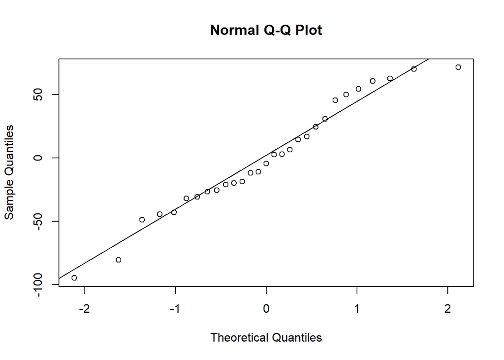

```r
> qqnorm(e)
> qqline(e)
```

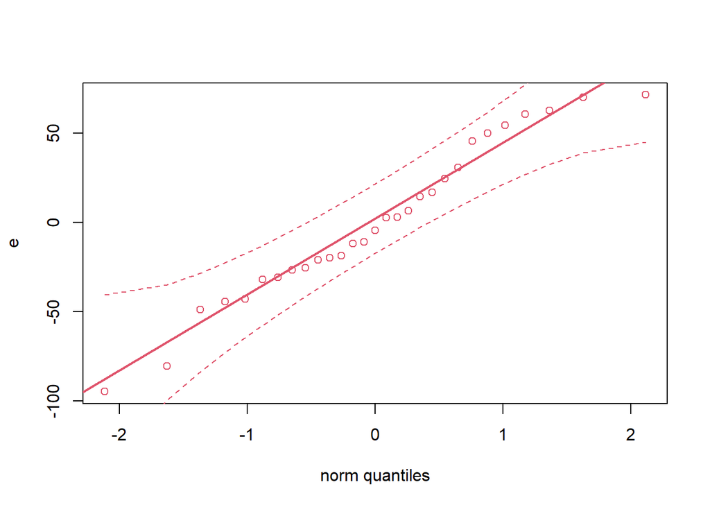

```r
> qqplot.das(e)
```

We can perform also Shapiro test

$H_0: \varepsilon$ is normally distributed

$H_A: \varepsilon$ is not normally distributed

Now we use the function `shapiro.test` in R

```r
> shapiro.test(e)

    Shapiro-Wilk normality test

data:  e
W = 0.96737, p-value = 0.4907
```

The $p-value = 0.4907 > 0.05 = \alpha$, therefore, we have no evidence to reject $H_0$, so the requirement $\varepsilon$ to be normally distributed is satisfied.

16. Let us now determine $95\%$ confidence intervals for the expected price $\hat{Y}$ of these homes having in mind the numbers of their `rooms`, `full` bathrooms and the points for `neighborhood`s.

$$S_{\hat{Y}}^2 = S_{\varepsilon}^2\vec{X}(\mathbb{X}^{T}\mathbb{X})^{-1}\vec{X}^T$$
Therefore,
$$\hat{Y} = (Y|\vec{X}) \in N(\vec{\beta}^T\vec{X}; \sigma_\varepsilon^2\vec{X}(\mathbb{X}^{T}\mathbb{X})^{-1}\vec{X}^T)$$
And the $(1-\alpha)100\%$ confidence interval for $\hat{Y}$ is
$$[\vec{\beta}^T\vec{X} - t_{1-\frac{\alpha}{2}; t(n-r-1)}S_{\hat{Y}};\ \vec{\beta}^T\vec{X} + t_{1-\frac{\alpha}{2}; t(n-r-1)}S_{\hat{Y}}], \quad i = 1, 2, ..., r$$
Now we use the function `predict` in R

```r
> predict(complex.modelfull, interval = "confidence", level = 0.95)
         fit       lwr      upr
1   77.22524  38.81385 115.6366
2  101.52431  61.37379 141.6748
3  331.11633 302.34844 359.8842
4  306.81726 285.99545 327.6391
5  365.57428 336.33731 394.8112
6  291.93557 259.05370 324.8174
7  214.34378 157.25044 271.4371
8  184.58040 158.09572 211.0651
9  267.63650 238.07703 297.1960
10  87.38412  34.26763 140.5006
11 208.87948 176.49141 241.2675
12 536.40927 490.28071 582.5378
13 199.46209 167.69450 231.2297
14 258.21911 231.79006 284.6482
15 194.73928 146.18554 243.2930
16 175.16302 140.85462 209.4714
17 184.58040 158.09572 211.0651
18 282.51818 262.75672 302.2796
19 463.51206 415.76753 511.2566
20 380.45597 341.42657 419.4854
21 291.93557 259.05370 324.8174
22 306.81726 285.99545 327.6391
23 258.21911 231.79006 284.6482
24 477.65225 426.82482 528.4797
25 267.63650 238.07703 297.1960
26 389.87335 362.34628 417.4004
27 389.87335 362.34628 417.4004
28 208.87948 176.49141 241.2675
29 267.63650 238.07703 297.1960
```

# Polynomial models

**Multiple Linear Regression Models** are called in this way because the mean of $Y$ is linear with respect to the parameters $\beta_0,\ \beta_1,\ \ldots,\ \beta_r$. Therefore, **polynomial models** (when $X_k = X^k,$ $k = 1, 2, ..., r$)
$$Y = \beta_0 + \beta_1 X + \beta_2 X^2 + ... + \beta_r X^r + \varepsilon,$$
are a particular case of Multiple Linear Regression Models.

## Example 3:

In $1609$ Galileo proved that the trajectory of a body falling with a horizontal component is a parabola. In the course of gaining insight into this fact, he set up an experiment which measured two variables, a `height` and a `distance`, yielding the following data

| height (punti) | 100 | 200 | 300 | 450 | 600 | 800 | 1000 |
| --- | --- | --- | --- | --- | --- | --- | --- |
| dist (punti) | 253 | 337 | 395 | 451 | 495 | 534 | 574 |

In plotting the data, Galileo apparently saw the parabola and with this insight proved it mathematically. Let’s see if linear regression can help us find the coefficients.

```r
> height <- c(100, 200, 300, 450, 600, 800, 1000)
> dist <- c(253, 337, 395, 451, 495, 534, 574)
```

The `I` function allows us to use the usual notation for power, because the `^` is used differently in the model notation.

```r
> lm.2 <- lm(dist ~ height + I(height^2));
> summary(lm.2)

Call:
lm(formula = dist ~ height + I(height^2))

Residuals:
      1       2       3       4       5       6       7
-14.420   9.192  13.624   2.060  -6.158 -12.912   8.614

Coefficients:
              Estimate Std. Error t value Pr(>|t|)
(Intercept)  2.002e+02  1.695e+01  11.811 0.000294 ***
height       7.062e-01  7.568e-02   9.332 0.000734 ***
I(height^2) -3.410e-04  6.754e-05  -5.049 0.007237 **
---
Signif. codes:  0 '***' 0.001 '**' 0.01 '*' 0.05 '.' 0.1 ' ' 1

Residual standard error: 13.79 on 4 degrees of freedom
Multiple R-squared:  0.9902,    Adjusted R-squared:  0.9852
F-statistic: 201.1 on 2 and 4 DF,  p-value: 9.696e-05
> points <- 100:1000
> quad.fit <- lm.2$coefficients[1] + lm.2$coefficients[2] * points + lm.2$coefficients[3] * points^2
```

We observe that all coefficients are statistically significant. The model is

$$dist = 200.2 + 0.7062\ height - 0.000341\ height^2 + \varepsilon$$

```r
> lm.3 <- lm(dist ~ height + I(height^2) + I(height^3));
> summary(lm.3)

Call:
lm(formula = dist ~ height + I(height^2) + I(height^3))

Residuals:
       1        2        3        4        5        6        7
-2.35639  3.52782  1.83769 -4.43416  0.01945  2.21560 -0.81001

Coefficients:
              Estimate Std. Error t value Pr(>|t|)
(Intercept)  1.555e+02  8.182e+00  19.003 0.000318 ***
height       1.119e+00  6.454e-02  17.332 0.000419 ***
I(height^2) -1.254e-03  1.360e-04  -9.220 0.002699 **
I(height^3)  5.550e-07  8.184e-08   6.782 0.006552 **
---
Signif. codes:  0 '***' 0.001 '**' 0.01 '*' 0.05 '.' 0.1 ' ' 1

Residual standard error: 3.941 on 3 degrees of freedom
Multiple R-squared:  0.9994,    Adjusted R-squared:  0.9988
F-statistic:  1658 on 3 and 3 DF,  p-value: 2.512e-05
> cube.fit <- lm.3$coefficients[1] + lm.3$coefficients[2] * points + lm.3$coefficients[3] * points^2 + lm.3$coefficients[4] * points^3
```

Again we observe that all coefficients are statistically significant. The model is

$$dist = 155.5 + 1.119\ height - 0.001254\ height^2 + 0.000000555\ height^3 + \varepsilon.$$

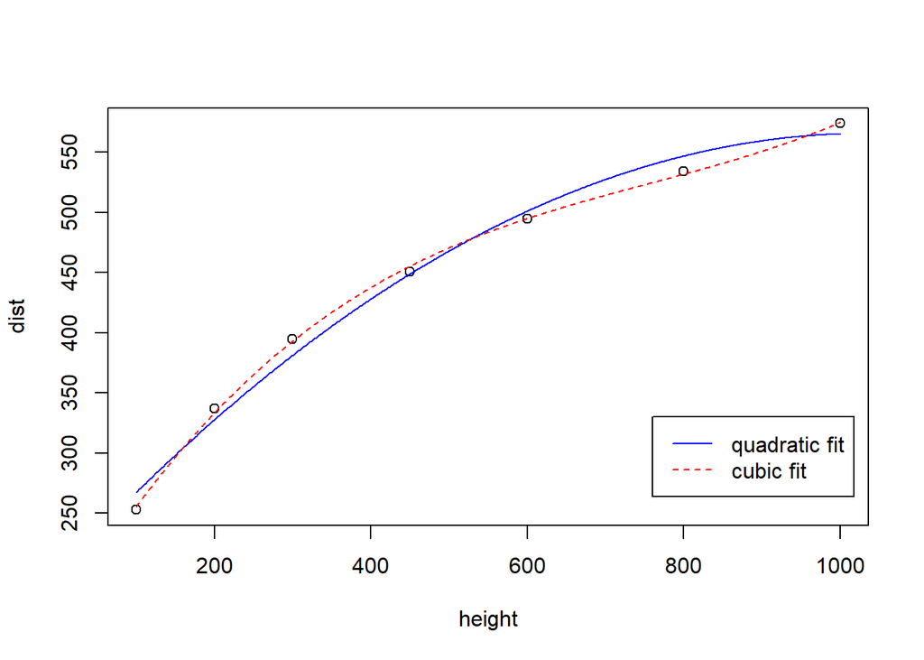

```r
> plot(height, dist)
> lines(points, quad.fit, lty = 1, col = "blue")
> lines(points, cube.fit, lty = 2, col = "red")
> legend(x = 760, y = 330, c("quadratic fit", "cubic fit"), lty = 1:2, col = c("blue", "red"))
```

Both curves seem to fit the data well. Which one to choose? A hypothesis test of $\beta_3 = 0$ will help us to decide between the two choices. Therefore we test,

In the function `summary(lm.3)` the $p-value = 0.006552$ is flagged automatically by R. It is less than $\alpha = 0.05$, therefore, we reject $H_0$ and the alternative $\beta_3 \neq 0$ is accepted. According to this data we are tempted to attribute this cubic presence to resistance which is ignored in the mathematical solution which finds the quadratic relationship.

## Example 4:

If there is no intercept term ($\beta_0 = 0$) in the model, you can explicitly remove it by adding `0` or `-1` to the formula.

```r
> n <- 50
> x1 <- rnorm(n, 172, 7)
> x2 <- rnorm(n, 168, 7)
> eps <- rnorm(n, 0, 3)
> y <- x1 + x2 + eps
> lm.fit <- lm(y ~ x1 + x2 - 1)
> summary(lm.fit)

Call:
lm(formula = y ~ x1 + x2 - 1)

Residuals:
    Min      1Q  Median      3Q     Max
-7.3482 -2.3311 -0.2261  2.4517  7.6135

Coefficients:
   Estimate Std. Error t value Pr(>|t|)
x1  0.93864    0.06204   15.13   <2e-16 ***
x2  1.06527    0.06307   16.89   <2e-16 ***
---
Signif. codes:  0 '***' 0.001 '**' 0.01 '*' 0.05 '.' 0.1 ' ' 1

Residual standard error: 3.431 on 48 degrees of freedom
Multiple R-squared:  0.9999,    Adjusted R-squared:  0.9999
F-statistic: 2.471e+05 on 2 and 48 DF,  p-value: < 2.2e-16
```

You can compare the above model without intercept with the following model with intercept.

```r
> summary(lm(y ~ x1 + x2))

Call:
lm(formula = y ~ x1 + x2)

Residuals:
    Min      1Q  Median      3Q     Max
-7.4546 -1.9526 -0.2168  2.4126  7.1390

Coefficients:
            Estimate Std. Error t value Pr(>|t|)
(Intercept) 15.46230   22.09459   0.700    0.487
x1           0.88406    0.09987   8.852 1.41e-11 ***
x2           1.02925    0.08167  12.603  < 2e-16 ***
---
Signif. codes:  0 '***' 0.001 '**' 0.01 '*' 0.05 '.' 0.1 ' ' 1

Residual standard error: 3.449 on 47 degrees of freedom
Multiple R-squared:  0.8336,    Adjusted R-squared:  0.8265
F-statistic: 117.7 on 2 and 47 DF,  p-value: < 2.2e-16
```

We observe that the model without intercept is better.

# ANalysis Of VAriance (ANOVA)

If the residual of the model is $\varepsilon \in N(0, \sigma_\varepsilon^2)$ we can make **ANalysis Of VAriance (ANOVA) /дисперсионен анализ/** and to check if the influence of a group of independent variables $X^{(1)}, ..., X^{(k)}$, $k < r$ is statistically significant for $Y$.

Consider the models (longer)
$$Y = \beta_0 + \beta_1 X^{(1)} + \beta_2 X^{(2)} + ... + \beta_r X^{(r)} + \varepsilon, \quad \quad (2)$$

and (shorter)
$$Y = \tilde{\beta}_0 + \tilde{\beta}_1 X^{(1)} + \tilde{\beta}_2 X^{(2)} + ... + \tilde{\beta}_k X^{(k)} + \tilde{\varepsilon}. \quad \quad (3)$$
We can test the hypothesis

$H_0: \beta_{k+1} = \beta_{k+2} = \ldots = \beta_r = 0$

$H_A:$ At least one of these coefficients is statistically significantly different from $0$.

If

- $SSE_{k}$ is the sum of squares of the residuals in the shorter model (3), and
- $SSE_{r}$ is the sum of squares of the residuals in the longer model (2).

$$\left(\left. \frac{\frac{SSE_{k} - SSE_{r}}{r - k}}{\frac{SSE_{r}}{n - r - 1}} \right| H_0\right) \in F(r - k;\ n - r - 1)$$

Therefore, the critical area for $H_0$ is
$$W_\alpha = \left\{\frac{\frac{SSE_{k} - SSE_{r}}{r - k}}{\frac{SSE_{r}}{n - r - 1}}\geq x_{1 - \frac{\alpha}{2};\ F(r - k;\ n - r - 1)}\right\}$$

If

$$F_{emp} = \frac{\frac{SSE_{k} - SSE_{r}}{r - k}}{\frac{SSE_{r}}{n - r - 1}},$$

is the computed value from the data, the $p-value = \mathbb{P}(\eta > F_{emp})$, where $\eta \in F(r - k;\ n - r - 1)$.

If we have no multicollinearity and $k = r - 1$ these test coincides with some $H_0: \beta_i = 0$ for some $i \in 1, 2, ..., r.$

# Example 5

Which one of the independent variables $C$ and $S$ in Example 1 is more important for the model.

```r
> S <- c(8, 8, 10, 13, 13, 13, 13, 13, 13, 13, 13, 12, 12, 12, 12,
+ 12, 12, 12, 12, 12, 12, 12, 15, 17, 18, 19, 19, 19, 15, 17, 17,
+ 17, 17, 17, 17, 17, 16, 16, 16, 16, 16, 16, 16, 16, 16, 16, 16, 13)
> C <- c(60, 70, 85, 87, 89, 90, 82, 81, 80, 87, 82, 81, 82, 82, 72,
+ 82, 92, 90, 92, 89, 89, 88, 88, 91, 91, 97, 100, 96, 92, 93, 94,
+ 95, 96, 97, 97, 97, 96, 96, 95, 93, 96, 94, 95, 92, 91, 90, 92, 93)
> Earn <- c(500, 570, 550, 770, 690, 900, 620, 610, 800, 870, 820,
+ 810, 820, 722, 722, 822, 722, 950, 752, 769, 769, 878, 878, 971,
+ 991, 977, 1100, 796, 712, 713, 714, 725, 716, 717, 797, 797,
+ 696, 696, 695, 693, 696, 694, 695, 792, 891, 890, 792, 693)
> df <- data.frame(Earn, S, C)
> n <- length(S); n
[1] 48
```

In order to answer this question we can use the function `anova` in R. It can compare two models and report if they are significantly different. The output from `anova` includes a p-value. Conventionally, a $p-value < 0.05$ indicates that the models are significantly different, whereas a $p-value > 0.05$ provides no such evidence.

```r
> EarnCS <- lm(Earn ~ C + S)
> EarnS <- lm(Earn ~ S)
> anova(EarnCS, EarnS)
Analysis of Variance Table

Model 1: Earn ~ C + S
Model 2: Earn ~ S
  Res.Df    RSS Df Sum of Sq      F Pr(>F)
1     45 525183
2     46 525757 -1   -574.17 0.0492 0.8255
```

The $p-value = 0.8255 > 0.05 = \alpha$, therefore, the models are not significantly different. Therefore, `C` is not so important for `Earn`. In other words: if we add terms and the new model is essentially unchanged, then the extra terms are not worth the additional complications. This p-value shows the significance of the coefficient $\beta_2$ before the added independent variable `C` in the model

$$Earn = \beta_0 + \beta_1S + \beta_2C + \varepsilon$$

Or

```r
> EarnCS <- lm(Earn ~ C + S)
> EarnC <- lm(Earn ~ C)
> anova(EarnCS, EarnC)
Analysis of Variance Table

Model 1: Earn ~ C + S
Model 2: Earn ~ C
  Res.Df    RSS Df Sum of Sq      F  Pr(>F)
1     45 525183
2     46 561483 -1    -36300 3.1103 0.08459 .
---
Signif. codes:  0 '***' 0.001 '**' 0.01 '*' 0.05 '.' 0.1 ' ' 1
```

The $p-value = 0.08459 > 0.05 = \alpha$, therefore, the models are not significantly different. However, when we compare this p-value with the previous one we can say that now we are not so confident as in the previous case. Therefore, `S` is more important for `Earn`, than `C`.This p-value shows the significance of the coefficient $\beta_1$ for the added independent variable `S` in the model

$$Earn = \beta_0 + \beta_1 S + \beta_2 C + \varepsilon$$

In other words: if we add terms and the new model is essentially unchanged, then the extra terms are not worth the additional complications.

The `anova` function has one strong requirement when comparing two models: one model must be contained within the other. That is, all the terms of the smaller model must appear in the larger model. Otherwise, the comparison is impossible.

In order to make the same we can consider also only the larger model in function `anova`.

```r
> EarnSC <- lm(Earn ~ S + C)
> anova(EarnSC)
Analysis of Variance Table

Response: Earn
          Df Sum Sq Mean Sq F value   Pr(>F)
S          1 126058  126058 10.8012 0.001971 **
C          1    574     574  0.0492 0.825470
Residuals 45 525183   11671
---
Signif. codes:  0 '***' 0.001 '**' 0.01 '*' 0.05 '.' 0.1 ' ' 1
```

The row `S` corresponds to the degrees of freedom, sum of squares of the errors $SSE_{k} = SSE_{1}$, mean square error $\frac{SSE_{k}}{n-k-1} = \frac{SSE_{k}}{n-2}$, $F_{emp}$ and the $p-value$ of $\tilde{\beta}_1$ for the model

$$Earn = \tilde{\beta}_0 + \tilde{\beta}_1S + \tilde{\varepsilon}$$
The last p-value in this row shows the significance of $\tilde{\beta}_1$ in the above model.

In the row `C` the last p-value shows the significance of $\beta_2$ in the model

$$Earn = \beta_0 + \beta_1S + \beta_2C + \varepsilon$$

The more important independent variable is `S`. When we insert it in the model we can exclude `C`.

or

```r
> EarnCS <- lm(Earn ~ C + S)
> anova(EarnCS)
Analysis of Variance Table

Response: Earn
          Df Sum Sq Mean Sq F value   Pr(>F)
C          1  90332   90332  7.7400 0.007864 **
S          1  36300   36300  3.1103 0.084586 .
Residuals 45 525183   11671
---
Signif. codes:  0 '***' 0.001 '**' 0.01 '*' 0.05 '.' 0.1 ' ' 1
```

The inclusion only of `C` in the model does not lead us to such a high significance of the coefficient before `C` as in the previous case. When we insert after `C` the independent variable `S` in the model the coefficient before `S` is insignificant, however the change is not so huge as in the previous `anova`.

When compare the $p-value$ in the row `S` with the corresponding one in

```r
> mymodel <- lm(Earn ~ S + C, data = df)
> summary(mymodel)

Call:
lm(formula = Earn ~ S + C, data = df)

Residuals:
     Min       1Q   Median       3Q      Max
-139.897 -104.855   -7.961   91.739  241.778

Coefficients:
            Estimate Std. Error t value Pr(>|t|)
(Intercept) 451.0495   208.2405   2.166   0.0356 *
S            17.4389     9.8882   1.764   0.0846 .
C             0.7583     3.4189   0.222   0.8255
---
Signif. codes:  0 '***' 0.001 '**' 0.01 '*' 0.05 '.' 0.1 ' ' 1

Residual standard error: 108 on 45 degrees of freedom
Multiple R-squared:  0.1943,    Adjusted R-squared:  0.1585
F-statistic: 5.425 on 2 and 45 DF,  p-value: 0.007748
```

we observe that they are the same.